[figure not shown]

# **1. Imports**

```python
import random
import requests
import bs4
import json
import datetime as dt
import sys
import numpy as np
import pandas as pd
import geopy
import geopandas as gpd
import seaborn as sns
import matplotlib.pyplot as plt
import re
import math
import warnings
import folium
import scipy.stats as stats
import ipywidgets as widgets
import dash
from dash import dcc, html
import dash_bootstrap_components as dbc
from dash.dependencies import Input, Output, State
from folium.plugins import MarkerCluster
from IPython.display import display, clear_output
from scipy.stats import chi2_contingency
from sklearn.feature_selection import RFE
from sklearn.linear_model import LogisticRegression
from sklearn.linear_model import LassoCV
from sklearn.tree import DecisionTreeClassifier
from shapely import wkt
from shapely.geometry import Point
from sklearn.preprocessing import MinMaxScaler
from sklearn.model_selection import train_test_split, StratifiedKFold
from sklearn.neighbors import KNeighborsRegressor
from sklearn.linear_model import LinearRegression
from sklearn.linear_model import Ridge
from sklearn.linear_model import Lasso
from sklearn.linear_model import ElasticNet
from sklearn.ensemble import RandomForestClassifier
from sklearn.preprocessing import PolynomialFeatures
from sklearn.metrics import r2_score, mean_absolute_error, mean_squared_error

warnings.filterwarnings('ignore')
```

# **2. Lisbon Properties for Sale - SUPERCASA Webscrapping**

```python
num_prop_per_page = 25
total_pages = 75
time_estimation = '3 to 5'

print(f'Time estimation for this task: {time_estimation} minutes.')
estimation = (dt.datetime.now() + dt.timedelta(minutes=4))
start = f'Tasks started at {dt.datetime.now().hour}h:{dt.datetime.now().minute}min. Estimated finish time {estimation.hour}h:{estimation.minute}min.'
print(start)

title, price, num_rooms, total_area, latitude, longitude, region, extras, id = ([] for i in range(9))

for n in range(1, 75):
    url = f'https://supercasa.pt/comprar-casas/lisboa/pagina-{n}'
    result = requests.get(url)
    soup = bs4.BeautifulSoup(result.text, 'lxml')

    # Find all properties on the current page
    properties = soup.find_all('div', class_='property big-picture')

    for prop in properties:
        # Title
        a = prop.find('h2', class_='property-list-title').find('a')
        title.append(a.get_text().strip() if a else ' ')

        # Price
        span = prop.find('div', class_='property-price').find('span')
        price.append(span.get_text(strip=True) if span else ' ')

        # Features
        feature = prop.find('div', class_='property-features')
        spans = feature.find_all('span') if feature else []
        rooms = spans[0].get_text() if len(spans) > 0 else "Unknown"
        area = spans[1].get_text() if len(spans) > 1 else "Unknown"
        num_rooms.append(rooms)
        total_area.append(area)

        # Links for latitude and longitude
        link = prop.find('a', class_='property-link')
        latitude.append(link.get('data-latitude') if link else 'Unknown')
        longitude.append(link.get('data-longitude') if link else 'Unknown')

        # Extras
        highlight = prop.find('div', class_='property-highlights')
        if highlight:
            extra_spans = highlight.find_all('span')
            extras.append(', '.join([span.get_text(strip=True) for span in extra_spans]))
        else:
            extras.append(' ')

        # Address region from JSON-LD script if necessary
        script = prop.find('script', type='application/ld+json')
        if script:
            data = json.loads(script.string)
            if data.get('@type') == 'Offer':
                available_at_or_from = data.get('availableAtOrFrom', {})
                address_info = available_at_or_from.get('address', {})
                address_region = address_info.get('addressRegion', 'Not provided')
                region.append(address_region)
        else:
            region.append('Not provided')

        sys.stdout.write(f"\rProgress: {int((n / total_pages) * 100)}%")
        sys.stdout.flush()

for i in range(len(title)):
    id.append(i)

sys.stdout.write(f"\rProgress: 100%")
sys.stdout.flush()
print('\nCompleted!')

headers = ['id', 'title', 'price', 'num_rooms', 'total_area', 'latitude', 'longitude', 'region', 'extras']
final_data = [id, title, price, num_rooms, total_area, latitude, longitude, region, extras]
Lisbon_Properties = pd.DataFrame(dict(zip(headers, final_data)))

print(f"\nYou now have data on {len(Lisbon_Properties['title'])} properties located in Lisbon!")
```

```
Time estimation for this task: 3 to 5 minutes.
Tasks started at 18h:22min. Estimated finish time 18h:26min.
```

[output not shown]

[output cut: 122 more lines]

**Save a backup**

```python
# Lisbon_Properties.to_csv('Lisbon_Properties.csv')
```

```python
Lisbon_Properties = pd.read_csv('Data/Lisbon_Properties.csv', index_col=0)
Lisbon_Properties.head()
```

**Go back: Table of Contents**

## **2.1. Lisbon Properties for Sale - Data Preprocessing**

### **2.1.1. Removing duplicated properties**

```python
Lisbon_Properties = Lisbon_Properties[~Lisbon_Properties.drop('id', axis=1).duplicated()]
Lisbon_Properties.reset_index(drop=True, inplace=True)
```

### **2.1.2. Checking Data Quality**

```python
Lisbon_Properties['extras'].unique()
```

```python
Lisbon_Properties['latitude'].unique()
```

```python
Lisbon_Properties['longitude'].unique()
```

```python
Lisbon_Properties['price'].unique()
```

```python
Lisbon_Properties['num_rooms'].value_counts()
```

```python
Lisbon_Properties['total_area'].unique()
```

```python
Lisbon_Properties['title'].unique()
```

```python
Lisbon_Properties['region'].value_counts()
```

### **2.1.3. Fixing issues found in previous step**

There are some wrong values in 'num_rooms' and 'total_area' features:

1. In 'num_rooms', we have areas, which shouldn't happen
2. In 'total_area', we have some unexpected values like'C.E.:

```python
Lisbon_Properties[Lisbon_Properties['num_rooms'].apply(lambda x: 'Área' in x)].head(10)
```

After filtering the Lisbon_Properties data frame, we found out that these rows were T0s and properties that do not specify the number of rooms.

To fix this, in the next step, we check whether the string 'Área' is in the 'num_rooms' column of each row.

If this is **True**, we append each index of the row to a list called 'modify_indeces' and:

- If 'T0' is in the title of this specific row, we assign the 'num_rooms' column to be the 'total_area' column, and assign the string '0 rooms' to the 'num_rooms' column;
- Else - for properties that do not speficy the number of rooms - we assign minus 1 ('-1') - the reason of this is that we will fill these missing values with machine learning techniques.

```python
modify_indices = []

for i, rooms in enumerate(Lisbon_Properties['num_rooms']):
    if isinstance(rooms, str) and 'Área' in rooms:
        modify_indices.append(i)

for i in modify_indices:
    if 'T0' in Lisbon_Properties.at[i, 'title']:
        Lisbon_Properties.at[i, 'total_area'] = Lisbon_Properties.at[i, 'num_rooms']
        Lisbon_Properties.at[i, 'num_rooms'] = '0 quartos'
    else:
        Lisbon_Properties.at[i, 'total_area'] = Lisbon_Properties.at[i, 'num_rooms']
        Lisbon_Properties.at[i, 'num_rooms'] = '-1'

Lisbon_Properties.reset_index(drop=True, inplace=True)
```

```python
Lisbon_Properties[Lisbon_Properties['title'].apply(lambda x: 'T0' in x)].head(10) # Check whether T0s rows are already fixed
```

After these corrections, we will drop the properties that do not have either the correct number of rooms or the correct total area.

```python
drop_indices = []

for i,area in enumerate(Lisbon_Properties['total_area']):
    if isinstance(area, str) and 'Área' not in area:
        drop_indices.append(i)

Lisbon_Properties.drop(index=drop_indices, inplace=True)
```

### **2.1.4. Checking if our fixes went well**

```python
Lisbon_Properties['num_rooms'].value_counts()
```

```python
Lisbon_Properties['total_area'].unique() # Checking if our fixes went well
```

### **2.1.5. Define functions to modify some columns and create new features**

```python
Lisbon_Properties.head()
```

```python
def extra_rooms(x):
    if '+' in x:
        return int(x.split('+')[1])
    else:
        return 0

def area(x):
    if 'Área' in x:
        return int(x.split()[2].replace('.',''))
    else:
        return 'Unknown'

def num_extras(x):
    if x.isspace():
        return 0
    elif ',' in x:
        return int(len(x.split(',')))
    else:
        return 1
```

```python
Lisbon_Properties['Type'] = Lisbon_Properties['title'].apply(lambda x: x.split()[0])
Lisbon_Properties['Typology'] = Lisbon_Properties['title'].apply(lambda x: x.split()[1])
Lisbon_Properties['Extra_Rooms'] = Lisbon_Properties['Typology'].apply(extra_rooms)
Lisbon_Properties['num_rooms'] = Lisbon_Properties['num_rooms'].apply(lambda x: int(x.split()[0]))
Lisbon_Properties['Total_N_Rooms'] = Lisbon_Properties['num_rooms'] + Lisbon_Properties['Extra_Rooms']
Lisbon_Properties['price'] = Lisbon_Properties['price'].apply(lambda x: int(x.replace('.','').split()[0]))
Lisbon_Properties['Area_m2'] = Lisbon_Properties['total_area'].apply(area)
Lisbon_Properties['N_Extras'] = Lisbon_Properties['extras'].apply(num_extras)
Lisbon_Properties['latitude'] = Lisbon_Properties['latitude'].apply(lambda x: float(x.replace(',','.')))
Lisbon_Properties['longitude'] = Lisbon_Properties['longitude'].apply(lambda x: float(x.replace(',','.')))
Lisbon_Properties['region'] = Lisbon_Properties['region'].apply(lambda x: x.replace(' ','_'))

Lisbon_Properties.rename(columns={'region':'Region','latitude':'Latitude','longitude':'Longitude','price':'Price','title':'Title','num_rooms':'N_Rooms','total_area':'Total_Area'}, inplace=True)
```

**Summary:**

```python
Lisbon_Properties.head(1)
```

```python
X = Lisbon_Properties[Lisbon_Properties['N_Rooms'] != -1].drop(['N_Rooms','Title','Total_Area','Type','Typology','Region','extras'], axis=1)
y = Lisbon_Properties[Lisbon_Properties['N_Rooms'] != -1]['N_Rooms']

X_train, X_test, y_train, y_test = train_test_split(X, y, test_size=0.3, random_state=42)

scaler = MinMaxScaler()
scaled_X_train = scaler.fit_transform(X_train)
scaled_X_test = scaler.transform(X_test)

test_errors = []
k_errors = []

for k in range(1,30):
    knn_model = KNeighborsRegressor(n_neighbors=k)
    knn_model.fit(scaled_X_train,y_train)

    y_pred = knn_model.predict(scaled_X_test)

    mse = mean_squared_error(y_test, y_pred)
    rmse = np.sqrt(mse)
    test_errors.append(rmse)
    k_errors.append([k,rmse])

plt.figure(figsize=(5, 3), dpi=200)
plt.plot(range(1, 30), test_errors, label='Test Error')
plt.legend()
plt.ylabel('RMSE')
plt.xlabel('K Value')
plt.title('Elbow Method for Optimal K in k-NN Regression')
plt.show()
```

```python
k_errors[0:5]
```

### **K = 1**

```python
knn_model = KNeighborsRegressor(n_neighbors=1)
knn_model.fit(scaled_X_train,y_train)

y_preds = knn_model.predict(scaled_X_test)
```

```python
results_df = pd.DataFrame({
    'Actual': y_test,
    'Predicted': y_preds
})

results_df['Predicted'] = results_df['Predicted'].apply(lambda x: round(x))
results_df['Accuracy'] = results_df.apply(lambda row: 1 if row['Actual'] == row['Predicted'] else 0, axis=1)
len(results_df[results_df['Accuracy'] == 1]) / len(results_df) * 100
```

### **K = 2**

```python
knn_model = KNeighborsRegressor(n_neighbors=2)
knn_model.fit(scaled_X_train,y_train)

y_preds = knn_model.predict(scaled_X_test)
```

```python
results_df = pd.DataFrame({
    'Actual': y_test,
    'Predicted': y_preds
})

results_df['Predicted'] = results_df['Predicted'].apply(lambda x: round(x))
results_df['Accuracy'] = results_df.apply(lambda row: 1 if row['Actual'] == row['Predicted'] else 0, axis=1)
len(results_df[results_df['Accuracy'] == 1]) / len(results_df) * 100
```

**Since we have higher accuracy for K = 1, we decided to use K = 1**

**First, we need to identify the indices that we need to fill (where N_Rooms = -1) and then we will scale the data and make our predictions for these rows**

```python
unknown_rooms_index = Lisbon_Properties[Lisbon_Properties['N_Rooms'] == -1].index
scaled_unknown_rooms = scaler.transform(Lisbon_Properties.loc[unknown_rooms_index].drop(['N_Rooms','Title','Total_Area','Type','Typology','Region','extras'], axis=1))

predictions = []
for room in scaled_unknown_rooms:
    room = room.reshape(1, -1)
    prediction = knn_model.predict(room)
    predictions.append(prediction[0])
```

**Confirmation of the rows**

```python
Lisbon_Properties.loc[unknown_rooms_index]
```

**Assign our predictions to each row**

```python
Lisbon_Properties.loc[unknown_rooms_index, 'N_Rooms'] = predictions
```

```python
Lisbon_Properties.loc[unknown_rooms_index]
```

**Now we need to make some modifications:**

1. Update N_Rooms to integer
2. Run again the code to calculate the total number of rooms (Total_N_Rooms)
3. Update Typology column

```python
Lisbon_Properties['N_Rooms'] = Lisbon_Properties['N_Rooms'].apply(lambda x: int(x))
Lisbon_Properties['Total_N_Rooms'] = Lisbon_Properties['N_Rooms'] + Lisbon_Properties['Extra_Rooms']
Lisbon_Properties.loc[unknown_rooms_index, 'Typology'] = 'T' + Lisbon_Properties['N_Rooms'].apply(lambda x: str(x))
```

```python
Lisbon_Properties.loc[unknown_rooms_index]
```

### **2.1.7. Finding the unique extras to create dummy variables for it**

```python
extras_df = Lisbon_Properties['extras'].str.split(',', expand=True)

extras = []
unique_extras = []

for x in [0,1,2,3,4]:
    extras.append(list(extras_df[x].unique()))

for ext in extras:
    unique_extras += ext

unique_extras = set(unique_extras)
unique_extras = {extra.strip().replace(' ','_') for extra in unique_extras if extra is not None and extra.strip()}
```

```python
unique_extras
```

```python
for feature in unique_extras:
    Lisbon_Properties[feature] = Lisbon_Properties['extras'].apply(lambda x: int(feature in x))
```

```python
region_dummies = pd.get_dummies(Lisbon_Properties['Region'],dtype=int)
type_dummies = pd.get_dummies(Lisbon_Properties['Type'],dtype=int)
```

```python
Lisbon_Properties = pd.concat([Lisbon_Properties, region_dummies, type_dummies], axis=1)
```

**Creating dummy variables for Region and Property Type**

```python
region_dummies = pd.get_dummies(Lisbon_Properties['Region'],dtype=int)
type_dummies = pd.get_dummies(Lisbon_Properties['Type'],dtype=int)
```

```python
Lisbon_Properties = pd.concat([Lisbon_Properties, region_dummies, type_dummies], axis=1)
```

**Drop Columns that we no longer need**

```python
# columns_to_drop = ['Title', 'Total_Area', 'Latitude', 'Longitude', 'Typology','extras','Region','Type']
# Lisbon_Properties = Lisbon_Properties.drop(columns_to_drop, axis=1)
```

```python
Lisbon_Properties.head()
```

```python
Lisbon_Properties.info()
```

**Go back: Table of Contents**

# **3. Lisbon Metro Info - Wikipedia Webscrapping**

```python
url = 'https://pt.wikipedia.org/wiki/Lista_de_esta%C3%A7%C3%B5es_do_Metropolitano_de_Lisboa'
response = requests.get(url)
soup = bs4.BeautifulSoup(response.text, 'html.parser')
data = str(soup.find('table', {'class': 'wikitable'}))

table = pd.read_html(data)[0]
columns = ['Nome','Outros nomes','Linha','Lat.','Long.']
Lisbon_Metro = table[columns]
```

**Save a backup**

```python
# Lisbon_Metro.to_csv('Lisbon_Metro.csv')
```

```python
Lisbon_Metro = pd.read_csv('Data/Lisbon_Metro.csv', index_col=0)
Lisbon_Metro
```

**Go back: Table of Contents**

## **3.1. Lisbon Metro Info - Data Preprocessing**

### **3.1.1. Removing last row that contains the same info as the heather of the data frame**

```python
Lisbon_Metro.drop(index=56, inplace=True)
```

```python
Lisbon_Metro
```

### **3.1.2. Creating a new column - Nome_Concat (Concats the name and the sub-name, aka 'Outros nomes', of each Lisbon Metro Station)**

```python
Lisbon_Metro['Nome_Concat'] = Lisbon_Metro['Nome']+' - '+Lisbon_Metro['Outros nomes']
Lisbon_Metro.head()
```

```python
Lisbon_Metro['Lat.'] = Lisbon_Metro['Lat.'].apply(lambda x: float(x))
Lisbon_Metro['Long.'] = Lisbon_Metro['Long.'].apply(lambda x: x.replace('−','-'))
Lisbon_Metro['Long.'] = Lisbon_Metro['Long.'].apply(lambda x: float(x))
```

**Note: before we convert 'Long.' to float, we had to replace the symbol '−' by a real minus '-'**

**Go back: Table of Contents**

# **4. Lisbon Cultural Facilities Info - Lisboa Aberta Webscrapping: Create Cultural Score**

## **4.1. Museaums Data**

```python
museums_url = 'https://services.arcgis.com/1dSrzEWVQn5kHHyK/arcgis/rest/services/POICultura/FeatureServer/3/query?where=1%3D1&outFields=*&f=pgeojson'

response = requests.get(museums_url)
response.raise_for_status()

mdf = gpd.read_file(response.text)

Lisbon_Museums = pd.DataFrame(mdf)
Lisbon_Museums.head()
```

**Save a backup**

```python
# Lisbon_Museums = Lisbon_Museums.to_csv('Lisbon_Museums.csv')
```

```python
Lisbon_Museums = pd.read_csv('Data/Lisbon_Museums.csv', index_col=0)
```

**Go back: Table of Contents**

## **4.2. Theaters Data**

```python
theaters_url = 'https://services.arcgis.com/1dSrzEWVQn5kHHyK/arcgis/rest/services/POICultura/FeatureServer/4/query?where=1%3D1&outFields=*&f=pgeojson'

response = requests.get(theaters_url)
response.raise_for_status()

tdf = gpd.read_file(response.text)

Lisbon_Theaters = pd.DataFrame(tdf)
Lisbon_Theaters.head()
```

**Save a backup**

```python
# Lisbon_Theaters.to_csv('Lisbon_Theaters.csv')
```

```python
Lisbon_Theaters = pd.read_csv('Data/Lisbon_Theaters.csv', index_col=0)
```

**Go back: Table of Contents**

## **4.3. Cinemas Data**

```python
cin_url = 'https://services.arcgis.com/1dSrzEWVQn5kHHyK/arcgis/rest/services/POICultura/FeatureServer/2/query?where=1%3D1&outFields=*&f=pgeojson'

response = requests.get(cin_url)
response.raise_for_status()

cdf = gpd.read_file(response.text)

Lisbon_Cinemas = pd.DataFrame(cdf)
Lisbon_Cinemas.head()
```

**Save a backup**

```python
# Lisbon_Cinemas.to_csv('Lisbon_Cinemas.csv')
```

```python
Lisbon_Cinemas = pd.read_csv('Data/Lisbon_Cinemas.csv', index_col=0)
```

**Go back: Table of Contents**

## **4.4. Auditoriums Data**

```python
aud_url = 'https://services.arcgis.com/1dSrzEWVQn5kHHyK/arcgis/rest/services/POICultura/FeatureServer/1/query?where=1%3D1&outFields=*&f=pgeojson'

response = requests.get(aud_url)
response.raise_for_status()

adf = gpd.read_file(response.text)

Lisbon_Auditoriums = pd.DataFrame(adf)
Lisbon_Auditoriums.head()
```

**Save a backup**

```python
# Lisbon_Auditoriums.to_csv('Lisbon_Auditoriums.csv')
```

```python
Lisbon_Auditoriums = pd.read_csv('Data/Lisbon_Auditoriums.csv', index_col=0)
```

**Go back: Table of Contents**

## **4.5. Creating a static column 'Type' to identify the facilities of each rows (e.g. Museums, Theaters, etc)**

```python
Lisbon_Museums['Type'] = 'Museum'
Lisbon_Theaters['Type'] = 'Theater'
Lisbon_Cinemas['Type'] = 'Cinema'
Lisbon_Auditoriums['Type'] = 'Auditorium'
```

## **4.6. Cultural Dataframe**

```python
culture_list = [Lisbon_Museums, Lisbon_Theaters, Lisbon_Cinemas, Lisbon_Auditoriums]
Lisbon_Culture = pd.concat(culture_list)
Lisbon_Culture.head()
```

### **4.6.1. Cultural Dataframe - Data Preprocessing**

**Transform the 'geometry' column to Shapely Point objects to subsequently extract latitude and longitude**

```python
Lisbon_Culture['geometry'] = Lisbon_Culture['geometry'].apply(wkt.loads)
```

```python
Lisbon_Culture.dtypes
```

**Drop columns that we no longer need**

```python
colms_to_drop = ['COD_SIG', 'INF_MORADA', 'INF_TELEFONE', 'INF_EMAIL', 'INF_SITE', 'INF_DESCRICAO', 'INF_ACTIVO', 'INF_FONTE']
Lisbon_Culture.drop(colms_to_drop, axis=1, inplace=True)
```

**Checking duplicates**

```python
duplicates = Lisbon_Culture.duplicated()
print("Duplicate rows:")
print(Lisbon_Culture[duplicates])
```

```python
duplicates = Lisbon_Culture.duplicated(subset=['GlobalID', 'geometry'])
print("Duplicate rows based on columns 'GlobalID' and 'geometry':")
print(Lisbon_Culture[duplicates])
```

There are no duplicates

**Spliting Geometry Into Lat. Long. Coordinates**

```python
def extract_lat_long(point):
    if isinstance(point, Point):
        latitude = point.y
        longitude = point.x
        return pd.Series([latitude, longitude])
    else:
        return pd.Series([None, None])
```

```python
Lisbon_Culture[['latitude', 'longitude']] = Lisbon_Culture['geometry'].apply(extract_lat_long)
```

```python
Lisbon_Culture.head()
```

**Drop 'geometry' column since it is no longer needed**

```python
Lisbon_Culture.drop('geometry', axis=1, inplace=True)
```

**Save a backup**

```python
# Lisbon_Culture.to_csv('Lisbon_Culture.csv')
```

**Go back: Table of Contents**

# **5. Lisbon Educational Facilities Info - Lisboa Aberta Webscrapping - Create Educational Facilities Score**

## **5.1. Pre-School (Public only)**

```python
pre_public_url = 'https://services.arcgis.com/1dSrzEWVQn5kHHyK/arcgis/rest/services/POIEducacao/FeatureServer/9/query?outFields=*&where=1%3D1&f=geojson'

response = requests.get(pre_public_url)
response.raise_for_status()

pre_pub = gpd.read_file(response.text)

Lisbon_PrePublic = pd.DataFrame(pre_pub)
```

**Save a backup**

```python
# Lisbon_PrePublic.to_csv('Lisbon_PrePublic.csv')
```

```python
Lisbon_PrePublic = pd.read_csv('Data/Lisbon_PrePublic.csv', index_col=0)
```

**Create 'Acess' and 'Stage' columns to identify rows as Pre-School and Public**

```python
Lisbon_PrePublic['Access'] = 'Public'
Lisbon_PrePublic['Stage'] = 'Pre-School'
```

**Rename Columns to Concat**

```python
Lisbon_PrePublic.rename(columns={'INF_NOME': 'Name', 'INF_MORADA': 'Address', 'INF_EMAIL': 'Email', 'INF_SITE': 'Website','INF_ACTIVO':'Flag_is_Active', 'FREGUESIA': 'Area'}, inplace=True)
```

**Drop useless columns**

```python
columns_to_drop = ['OBJECTID', 'COD_SIG', 'Address', 'INF_TELEFONE', 'Email', 'Website', 'Flag_is_Active', 'INF_DESCRICAO', 'INF_ID']
Lisbon_PrePublic.drop(columns_to_drop, axis=1, inplace=True)
```

**Create new columns order**

```python
new_order = ['Name', 'Area', 'GlobalID','geometry', 'Access', 'Stage']
Lisbon_PrePublic = Lisbon_PrePublic[new_order]

Lisbon_PrePublic.head()
```

```python
new_order = ['Name', 'Area', 'GlobalID','geometry', 'Access', 'Stage']
Lisbon_PrePublic = Lisbon_PrePublic[new_order]

Lisbon_PrePublic.head()
```

**Go back: Table of Contents**

## **5.2. 1st Cicle Public/Private**

```python
# Public Schools
first_public_url = 'https://services.arcgis.com/1dSrzEWVQn5kHHyK/arcgis/rest/services/POIEducacao/FeatureServer/1/query?outFields=*&where=1%3D1&f=geojson'

response = requests.get(first_public_url)
response.raise_for_status()

Lisbon_1stPublic = gpd.read_file(response.text)
Lisbon_1stPublic = pd.DataFrame(Lisbon_1stPublic)

# Private Schools
first_private_url = 'https://services.arcgis.com/1dSrzEWVQn5kHHyK/arcgis/rest/services/POIEducacao/FeatureServer/6/query?where=1%3D1&outFields=*&f=pgeojson'

response = requests.get(first_private_url)
response.raise_for_status()

Lisbon_1stPrivate  = gpd.read_file(response.text)
Lisbon_1stPrivate = pd.DataFrame(Lisbon_1stPrivate)
```

**Save a backup**

```python
# Lisbon_1stPublic.to_csv('Lisbon_1stPublic.csv')
# Lisbon_1stPrivate.to_csv('Lisbon_1stPrivate.csv')
```

```python
Lisbon_1stPublic = pd.read_csv('Data/Lisbon_1stPublic.csv',index_col=0)
Lisbon_1stPrivate = pd.read_csv('Data/Lisbon_1stPrivate.csv',index_col=0)
```

```python
Lisbon_1stPublic['Access'] = 'Public'
Lisbon_1stPublic['Stage'] = 'First'
Lisbon_1stPrivate['Access'] = 'Private'
Lisbon_1stPrivate['Stage'] = 'First'
```

**Rename Columns to Concat**

```python
Lisbon_1stPublic.rename(columns={'NOME_ESCOLA': 'Name', 'MORADA': 'Address', 'FREGUESIA12': 'Area'}, inplace=True)
Lisbon_1stPrivate.rename(columns={'INF_NOME': 'Name', 'INF_MORADA': 'Address', 'FREGUESIA': 'Area', 'INF_SITE': 'Website'}, inplace=True)
```

**Drop useless columns**

```python
needed_columns = ['Name', 'Area', 'GlobalID', 'geometry', 'Access', 'Stage']

Lisbon_1stPublic = Lisbon_1stPublic[needed_columns]
Lisbon_1stPrivate = Lisbon_1stPrivate[needed_columns]
```

**Create new columns order**

```python
new_order = ['Name', 'Area', 'GlobalID','geometry', 'Access', 'Stage']

Lisbon_1stPublic = Lisbon_1stPublic[new_order]
Lisbon_1stPrivate = Lisbon_1stPrivate[new_order]
```

**Go back: Table of Contents**

## **5.3. 2nd/3rd Cicle Public/Private**

```python
# Public
second_public_url = 'https://services.arcgis.com/1dSrzEWVQn5kHHyK/arcgis/rest/services/POIEducacao/FeatureServer/1/query?outFields=*&where=1%3D1&f=geojson'

response = requests.get(second_public_url)
response.raise_for_status()

Lisbon_2ndPublic  = gpd.read_file(response.text)
Lisbon_2ndPublic = pd.DataFrame(Lisbon_2ndPublic)

# Private
second_private_url = 'https://services.arcgis.com/1dSrzEWVQn5kHHyK/arcgis/rest/services/POIEducacao/FeatureServer/6/query?outFields=*&where=1%3D1&f=geojson'

response = requests.get(second_private_url)
response.raise_for_status()

Lisbon_2ndPrivate  = gpd.read_file(response.text)
Lisbon_2ndPrivate = pd.DataFrame(Lisbon_2ndPrivate)
```

**Save a backup**

```python
# Lisbon_2ndPublic.to_csv('Lisbon_2ndPublic.csv')
# Lisbon_2ndPrivate.to_csv('Lisbon_2ndPrivate.csv')
```

```python
Lisbon_2ndPublic = pd.read_csv('Data/Lisbon_2ndPublic.csv', index_col=0)
Lisbon_2ndPrivate = pd.read_csv('Data/Lisbon_2ndPrivate.csv', index_col=0)
```

```python
Lisbon_2ndPublic['Access'] = 'Public'
Lisbon_2ndPublic['Stage'] = 'Second'

Lisbon_2ndPrivate['Access'] = 'Private'
Lisbon_2ndPrivate['Stage'] = 'Second'
```

**Rename Columns to Concat**

```python
Lisbon_2ndPublic.rename(columns={'NOME_ESCOLA': 'Name', 'MORADA': 'Address', 'FREGUESIA12': 'Area', 'INF_SITE': 'Website'}, inplace=True)
Lisbon_2ndPrivate.rename(columns={'INF_NOME': 'Name', 'INF_MORADA': 'Address', 'FREGUESIA': 'Area', 'SITE': 'Website'}, inplace=True)
```

**Drop useless columns**

```python
needed_columns = ['Name', 'Area', 'GlobalID', 'geometry', 'Access', 'Stage']

Lisbon_2ndPublic = Lisbon_1stPublic[needed_columns]
Lisbon_2ndPrivate = Lisbon_1stPrivate[needed_columns]
```

**Create new columns order**

```python
new_order = ['Name', 'Area', 'GlobalID','geometry', 'Access', 'Stage']

Lisbon_2ndPublic = Lisbon_2ndPublic[new_order]
Lisbon_2ndPrivate = Lisbon_2ndPrivate[new_order]
```

**Go back: Table of Contents**

## **5.4. High School Public/Private**

```python
# Public
high_public_url = 'https://services.arcgis.com/1dSrzEWVQn5kHHyK/arcgis/rest/services/POIEducacao/FeatureServer/1/query?outFields=*&where=1%3D1&f=geojson'

response = requests.get(high_public_url)
response.raise_for_status()

Lisbon_HSchool_Public = gpd.read_file(response.text)
Lisbon_HSchool_Public = pd.DataFrame(Lisbon_HSchool_Public)

#Private
high_private_url = 'https://services.arcgis.com/1dSrzEWVQn5kHHyK/arcgis/rest/services/POIEducacao/FeatureServer/7/query?outFields=*&where=1%3D1&f=geojson'

response = requests.get(high_private_url)
response.raise_for_status()

Lisbon_HSchool_Private  = gpd.read_file(response.text)
Lisbon_HSchool_Private = pd.DataFrame(Lisbon_HSchool_Private)
```

**Save a backup**

```python
#Lisbon_HSchool_Public.to_csv('Lisbon_HSchool_Public.csv')
#Lisbon_HSchool_Private.to_csv('Lisbon_HSchool_Private.csv')
```

```python
Lisbon_HSchool_Public = pd.read_csv('Data/Lisbon_HSchool_Public.csv')
Lisbon_HSchool_Private = pd.read_csv('Data/Lisbon_HSchool_Private.csv')
```

```python
Lisbon_HSchool_Public['Access'] = 'Public'
Lisbon_HSchool_Public['Stage'] = 'Second'

Lisbon_HSchool_Private['Access'] = 'Private'
Lisbon_HSchool_Private['Stage'] = 'HighSchool'
```

**Rename Columns to Concat**

```python
Lisbon_HSchool_Public.rename(columns={'INF_NOME': 'Name', 'INF_MORADA': 'Address', 'FREGUESIA': 'Area', 'INF_SITE': 'Website'}, inplace=True)
Lisbon_HSchool_Private.rename(columns={'INF_NOME': 'Name', 'INF_MORADA': 'Address', 'FREGUESIA': 'Area', 'INF_SITE': 'Website'}, inplace=True)
```

**Drop useless columns**

```python
needed_columns = ['Name', 'Area', 'GlobalID', 'geometry', 'Access', 'Stage']

Lisbon_HSchool_Public = Lisbon_1stPublic[needed_columns]
Lisbon_HSchool_Private = Lisbon_1stPrivate[needed_columns]
```

**Create new columns order**

```python
new_order = ['Name', 'Area', 'GlobalID','geometry', 'Access', 'Stage']
Lisbon_HSchool_Public = Lisbon_HSchool_Public[new_order]
Lisbon_HSchool_Private = Lisbon_HSchool_Private[new_order]
```

**Go back: Table of Contents**

## **5.5. College Public/Private**

```python
uni_url = 'https://services.arcgis.com/1dSrzEWVQn5kHHyK/arcgis/rest/services/MapaConhecimento/FeatureServer/1/query?where=1%3D1&outFields=*&f=pgeojson'

response = requests.get(uni_url)
response.raise_for_status()

uni_all  = response.json()

Lisbon_AllUni = gpd.GeoDataFrame.from_features(uni_all['features'])

Lisbon_AllUni = pd.DataFrame(Lisbon_AllUni)
```

**Save a backup**

```python
# Lisbon_AllUni.to_csv('Lisbon_AllUni.csv')
```

```python
Lisbon_AllUni = pd.read_csv('Data/Lisbon_AllUni.csv', index_col=0)
```

```python
Lisbon_AllUni['Access'] = 'All'
Lisbon_AllUni['Stage'] = 'Uni'
```

**Rename Columns to Concat**

```python
Lisbon_AllUni.rename(columns={'NOME': 'Name', 'MORADA': 'Address', 'SITE': 'Website'}, inplace=True)
Lisbon_AllUni['Area'] = 'NaN'
```

**Drop useless columns**

```python
columns_to_drop_uni = ['OBJECTID', 'COD_SIG', 'IDTIPO', 'Address', 'ATORTIPOCODIGO', 'EMAIL', 'Website', 'REDESOCIAL', 'REDESOCIAL']
Lisbon_AllUni.drop(columns_to_drop_uni, axis=1, inplace=True)
```

**Create new columns order**

```python
needed_columns = ['Name', 'Area', 'GlobalID', 'geometry', 'Access', 'Stage']
Lisbon_AllUni = Lisbon_AllUni[new_order]
```

**Go back: Table of Contents**

## **5.6. Educational Dataframe**

**Check Common Columns for Concat**

```python
edu_list = [Lisbon_PrePublic, Lisbon_1stPrivate, Lisbon_1stPublic, Lisbon_2ndPrivate, Lisbon_2ndPublic, Lisbon_HSchool_Public, Lisbon_HSchool_Private, Lisbon_AllUni]

common_columns = set(edu_list[0].columns)
for df in edu_list[1:]:
    common_columns.intersection_update(df.columns)

print(f"Common columns: {common_columns}")
```

**Concat Dataframes**

```python
Lisbon_Education = pd.concat(edu_list)
Lisbon_Education
```

**Save a backup**

```python
# Lisbon_Education.to_csv('Lisbon_Education.csv')
```

```python
Lisbon_Education = pd.read_csv('Data/Lisbon_Education.csv', index_col=0)
```

### **5.6.1. Educational Dataframe - Data Preprocessing**

**Check Duplicates**

```python
duplicates = Lisbon_Education.duplicated(subset=['GlobalID', 'geometry'])
print("Duplicate rows based on columns 'GlobalID' and 'geometry':")
print(Lisbon_Education[duplicates])
```

**Drop duplicates**

```python
Lisbon_Education = Lisbon_Education.drop_duplicates(subset=['GlobalID', 'geometry'])
```

**Check nulls**

```python
Lisbon_Education['geometry'].isnull().sum()
```

**Drop nulls**

```python
Lisbon_Education = Lisbon_Education.dropna(subset=['geometry']).reset_index(drop=True)
```

```python
Lisbon_Education['geometry'].isnull().sum()
```

**Transform the 'geometry' column to Shapely Point objects to subsequently extract latitude and longitude**

```python
Lisbon_Education['geometry'] = Lisbon_Education['geometry'].apply(wkt.loads)
```

```python
Lisbon_Education[['latitude', 'longitude']] = Lisbon_Education['geometry'].apply(extract_lat_long)
```

```python
Lisbon_Education.info()
```

**Calculate distances with latitude and longitude features**

```python
def haversine(lat1, lon1, lat2, lon2):
    lat1 = math.radians(lat1)
    lon1 = math.radians(lon1)
    lat2 = math.radians(lat2)
    lon2 = math.radians(lon2)

    dlat = lat2 - lat1
    dlon = lon2 - lon1

    a = math.sin(dlat / 2)**2 + math.cos(lat1) * math.cos(lat2) * math.sin(dlon / 2)**2
    c = 2 * math.atan2(math.sqrt(a), math.sqrt(1 - a))
    R = 6371.0
    distance = R * c

    return distance
```

**We decided to define a threshold of 0.5 km**

```python
dist_threshold = 0.5
```

**Calculate Distances between each Property and each Metro Station and add them to Lisbon_Properties Dataframe**

```python
distances = []

for p_index, p_row in Lisbon_Properties.iterrows():
    count_nearby_stations = 0
    for m_index, m_row in Lisbon_Metro.iterrows():
        distance = haversine(p_row['Latitude'], p_row['Longitude'], m_row['Lat.'], m_row['Long.'])
        if distance < dist_threshold:
            count_nearby_stations += 1
        distances.append({
            'property_id': p_row['id'],
            #'property_title': p_row['title'],
            'metro_station': m_row['Nome'],
            'distance_km': distance
        })
    Lisbon_Properties.at[p_index, 'Stations_within_0.5km'] = count_nearby_stations
```

```python
Distances_df = pd.DataFrame(distances)
```

```python
Distances_df.head()
```

**Convert 'property_id' to integer**

```python
Distances_df['property_id'] = Distances_df['property_id'].apply(lambda x: int(x))
```

**Example: Distances of property_id = 0 to each metro station**

```python
Distances_df.loc[Distances_df['property_id'] == 0]
```

```python
Lisbon_Properties.head()
```

```python
Lisbon_Properties['Stations_within_0.5km'] = Lisbon_Properties['Stations_within_0.5km'].apply(lambda x: int(x))
```

**Calculate the number of cultural facilities in a 1.5Km radius**

```python
dist_threshold_2 = 1.5

cult_distances = []

for p_index, p_row in Lisbon_Properties.iterrows():
    count_nearby_cult = 0
    for c_index, c_row in Lisbon_Culture.iterrows():
        distance = haversine(p_row['Latitude'], p_row['Longitude'], c_row['latitude'], c_row['longitude'])
        if distance < dist_threshold_2:
            count_nearby_cult += 1
        cult_distances.append({
            'property_id': p_row['id'],
            'Name': c_row['INF_NOME'],
            'Area': c_row['FREGUESIA'],
            'distance_km': distance
        })
    Lisbon_Properties.at[p_index, 'Cultural_fac_within_1.5km'] = count_nearby_cult

Cult_Distances_df = pd.DataFrame(cult_distances)

Cult_Distances_df.head()
```

```python
Lisbon_Properties.head()
```

**Converting Cultural_fac_within_1.5km to integer**

```python
Lisbon_Properties['Cultural_fac_within_1.5km'] = Lisbon_Properties['Cultural_fac_within_1.5km'].apply(lambda x: int(x))
```

```python
dist_threshold_3 = 1.5

edu_distances = []

for p_index, p_row in Lisbon_Properties.iterrows():
    count_nearby_edu = 0
    for m_index, m_row in Lisbon_Education.iterrows():
        distance = haversine(p_row['Latitude'], p_row['Longitude'], m_row['latitude'], m_row['longitude'])
        if distance < dist_threshold_3:
            count_nearby_edu += 1
        edu_distances.append({
            'property_id': p_row['id'],
            'Name': m_row['Name'],
            'Area': m_row['Area'],
            'distance_km': distance
        })
    Lisbon_Properties.at[p_index, 'Edu_within_1.5km'] = count_nearby_edu

Edu_distances_df = pd.DataFrame(edu_distances)

Edu_distances_df
```

**Converting Edu_within_1.5km to integer**

```python
Lisbon_Properties['Edu_within_1.5km'] = Lisbon_Properties['Edu_within_1.5km'].apply(lambda x: int(x))
```

```python
Lisbon_Properties.info()
```

**Save a backup of Final Data**

```python
# Final_Data = Lisbon_Properties.copy()
# Final_Data = Final_Data.loc[:, ~Final_Data.columns.duplicated()]

# columns_to_drop = ['Title', 'Total_Area', 'Latitude', 'Longitude', 'Typology','extras','Region','Type','id']
# Final_Data = Final_Data.drop(columns_to_drop, axis=1)

# Final_Data.to_csv('Data/Final_Data.csv')
```

**Go back: Table of Contents**

# **6. Predictive Modeling**

**In this section, we will perform feature selection, build multiple regression models, and finally compare their evaluation metrics to choose the best-fit model for both the training and testing sets. We will then draw some conclusions.**

```python
Lisbon_Forecasting = Lisbon_Properties.copy()
Lisbon_Forecasting = Lisbon_Forecasting.loc[:, ~Lisbon_Forecasting.columns.duplicated()]

columns_to_drop = ['Title', 'Total_Area', 'Latitude', 'Longitude', 'Typology','extras','Region','Type','id']
Lisbon_Forecasting = Lisbon_Forecasting.drop(columns_to_drop, axis=1)
```

```python
Lisbon_Forecasting.head(10)
```

|  | Price | N_Rooms | Extra_Rooms | Total_N_Rooms | Area_m2 | N_Extras | Último_andar | Rés_do_chão | De_luxo | Vista_para_mar | ... | Estúdio | Flat | Loft | Moradia | Palacete | Penthouse | Quinta | Stations_within_0.5km | Cultural_fac_within_1.5km | Edu_within_1.5km |
| --- | --- | --- | --- | --- | --- | --- | --- | --- | --- | --- | --- | --- | --- | --- | --- | --- | --- | --- | --- | --- | --- |
| 0 | 430000 | 2 | 0 | 2 | 90 | 0 | 0 | 0 | 0 | 0 | ... | 0 | 0 | 0 | 0 | 0 | 0 | 0 | 1 | 42 | 45 |
| 1 | 269900 | 1 | 0 | 1 | 97 | 0 | 0 | 0 | 0 | 0 | ... | 0 | 0 | 0 | 0 | 0 | 0 | 0 | 0 | 8 | 17 |
| 2 | 399900 | 3 | 0 | 3 | 120 | 0 | 0 | 0 | 0 | 0 | ... | 0 | 0 | 0 | 0 | 0 | 0 | 0 | 1 | 16 | 23 |
| 3 | 285000 | 2 | 0 | 2 | 55 | 0 | 0 | 0 | 0 | 0 | ... | 0 | 0 | 0 | 0 | 0 | 0 | 0 | 2 | 96 | 27 |
| 4 | 690000 | 1 | 0 | 1 | 93 | 1 | 0 | 0 | 0 | 0 | ... | 0 | 0 | 0 | 0 | 0 | 0 | 0 | 2 | 106 | 28 |
| 5 | 3950000 | 5 | 0 | 5 | 416 | 2 | 0 | 0 | 0 | 0 | ... | 0 | 0 | 0 | 0 | 0 | 0 | 0 | 1 | 64 | 29 |
| 6 | 1650000 | 4 | 1 | 5 | 233 | 2 | 0 | 0 | 0 | 0 | ... | 0 | 0 | 0 | 0 | 0 | 0 | 0 | 3 | 92 | 23 |
| 7 | 1800000 | 2 | 1 | 3 | 234 | 2 | 0 | 0 | 0 | 0 | ... | 0 | 0 | 0 | 0 | 0 | 0 | 0 | 0 | 103 | 30 |
| 8 | 1500000 | 9 | 0 | 9 | 290 | 1 | 0 | 0 | 0 | 0 | ... | 0 | 0 | 0 | 0 | 0 | 0 | 0 | 2 | 88 | 31 |
| 9 | 2200000 | 5 | 0 | 5 | 336 | 3 | 0 | 0 | 0 | 0 | ... | 0 | 0 | 0 | 0 | 0 | 0 | 0 | 0 | 44 | 26 |

10 rows × 50 columns

```python
X = Lisbon_Forecasting.drop('Price',axis=1)
y = Lisbon_Forecasting['Price']
```

**Go back: Table of Contents**

## **6.1. Feature Selection**

```python
def apply_chisquare(X, y, var, alpha=0.05):
    dfObserved = pd.crosstab(y, X)
    chi2, p, dof, expected = stats.chi2_contingency(dfObserved.values)
    dfExpected = pd.DataFrame(expected, columns=dfObserved.columns, index=dfObserved.index)
    if p < alpha:
        result = (var, "IMPORTANT")
    else:
        result = (var, "NOT IMPORTANT")
    return result

def select_best_cat_features(X, y):
    results = []

    skf = StratifiedKFold(n_splits=3, random_state=99, shuffle=True)

    for train_index, val_index in skf.split(X, y):
        X_train, X_val = X.iloc[train_index], X.iloc[val_index]
        y_train, y_val = y.iloc[train_index], y.iloc[val_index]

        categorical_columns = X.columns[X.apply(lambda col: col.dropna().isin([0, 1]).all())]

        X_train_cat = X_train[categorical_columns].copy()

        for var in categorical_columns:
            if var in X_train_cat.columns:  # Ensure var is a column in X_train_cat
                result = apply_chisquare(X_train_cat[var], y_train, var)
                results.append(result)

    results_df = pd.DataFrame(results, columns=["Feature", "Importance"])
    return results_df

results_df = select_best_cat_features(X, y)
```

```python
not_important_categorical = []
for x in results_df[results_df['Importance']=='NOT IMPORTANT']['Feature'].unique():
    not_important_categorical.append(x)

not_important_categorical
```

```
['Último_andar',
 'Rés_do_chão',
 'De_luxo',
 'Vista_para_mar',
 'Com_elevador',
 'Com_garagem',
 'Alcântara',
 'Alvalade',
 'Areeiro',
 'Casa',
 'Estúdio',
 'Flat',
 'Loft',
 'Quinta',
 'Piscina',
 'Penha_de_França',
 'Santo_António',
 'Palacete',
 'Penthouse',
 'Beato',
 'Santa_Clara',
 'Duplex']
```

```python
Lisbon_Forecasting = Lisbon_Forecasting.drop(not_important_categorical, axis=1)
```

```python
numerical_columns = X.drop(X.columns[X.apply(lambda col: col.dropna().isin([0, 1]).all())],axis=1)
```

```python
def apply_variance(X_train, var):
    variance = X_train.var()
    return var, variance

def select_features_variance(X, y, numerical_columns):
    skf = StratifiedKFold(n_splits=3, random_state=99, shuffle=True)
    results = []

    count = 1
    for train_index, val_index in skf.split(X, y):
        X_train, X_val = X.iloc[train_index], X.iloc[val_index]
        y_train, y_val = y.iloc[train_index], y.iloc[val_index]

        # check which features to use using variance
        for var in numerical_columns:
            result = apply_variance(X_train[var], var)
            results.append(result)

        count += 1

    # Create a DataFrame from the results
    results_df = pd.DataFrame(results, columns=["Feature", "Variance"])
    return results_df

results_df = select_features_variance(X, y, numerical_columns)
results_df.sort_values(by='Variance').groupby('Feature').mean().sort_values(by='Variance')
```

| Feature | Variance |
| --- | --- |
| Extra_Rooms | 0.086097 |
| N_Extras | 0.970937 |
| Stations_within_0.5km | 0.995153 |
| N_Rooms | 2.064434 |
| Total_N_Rooms | 2.102593 |
| Edu_within_1.5km | 82.600418 |
| Cultural_fac_within_1.5km | 781.504964 |
| Area_m2 | 17947.851638 |

```python
high_variance_numerical = ['Extra_Rooms','N_Extras']
```

```python
Lisbon_Forecasting = Lisbon_Forecasting.drop(high_variance_numerical, axis=1)
```

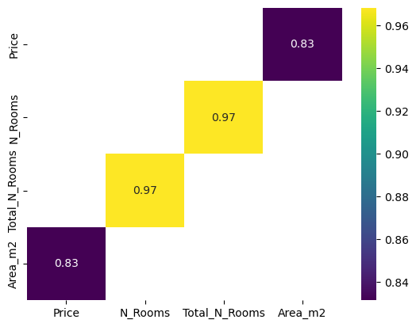

```python
correlation_matrix = Lisbon_Properties.corr(method="spearman",numeric_only=True)

high_corr = correlation_matrix[(correlation_matrix > 0.8) & (correlation_matrix != 1)]

high_corr = high_corr.dropna(how='all', axis=0).dropna(how='all', axis=1)

sns.heatmap(high_corr, cmap="viridis",annot=True)
plt.show()
```

```python
high_corr = ['N_Rooms']
Lisbon_Forecasting = Lisbon_Forecasting.drop(high_corr, axis=1)
```

```python
def plot_importance(variables,name):
    imp_features = variables.sort_values()
    plt.figure(figsize=(5,10))
    imp_features.plot(kind = "barh")
    plt.title("Feature importance using " + name + " Model")
    plt.show()

def apply_dt(X_train, y_train):
    dt = DecisionTreeClassifier(random_state = 99).fit(X_train, y_train)
    feature_importances = pd.Series(dt.feature_importances_, index = X_train.columns)
    plot_importance(feature_importances, 'DT')

def select_best_features_dt(X, y):
    count = 1
    for train_index, val_index in skf.split(X,y):
        X_train, X_val = X.iloc[train_index], X.iloc[val_index]
        y_train, y_val = y.iloc[train_index], y.iloc[val_index]

        ######################################### SELECT FEATURES #################################################
        print('_________________________________________________________________________________________________\n')
        print('                                     SPLIT ' + str(count) + '                                    ')
        print('_________________________________________________________________________________________________')

        # check which features to use using decision Tree
        apply_dt(X_train, y_train)

        count+=1

skf = StratifiedKFold(n_splits = 3, random_state = 99, shuffle = True)
```

```
_________________________________________________________________________________________________

                                     SPLIT 1
_________________________________________________________________________________________________
```

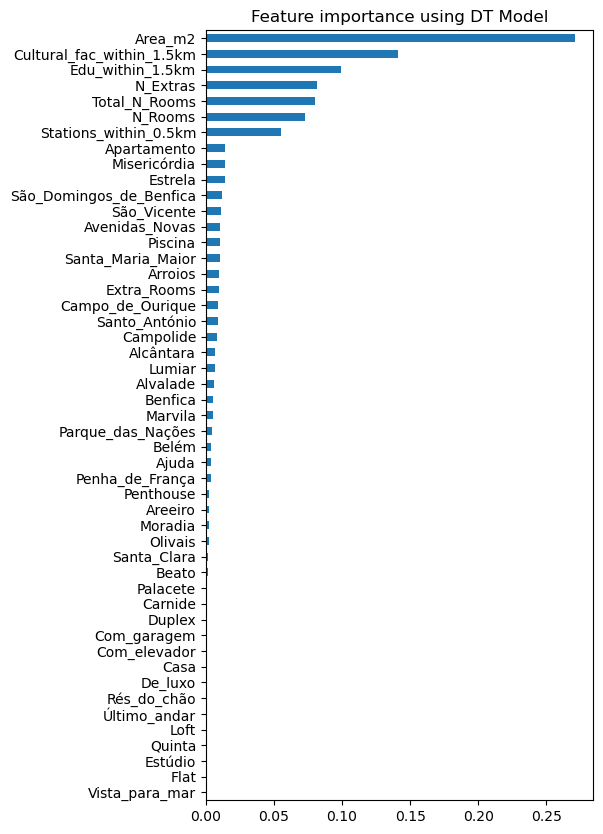

```
_________________________________________________________________________________________________

                                     SPLIT 2
_________________________________________________________________________________________________
```

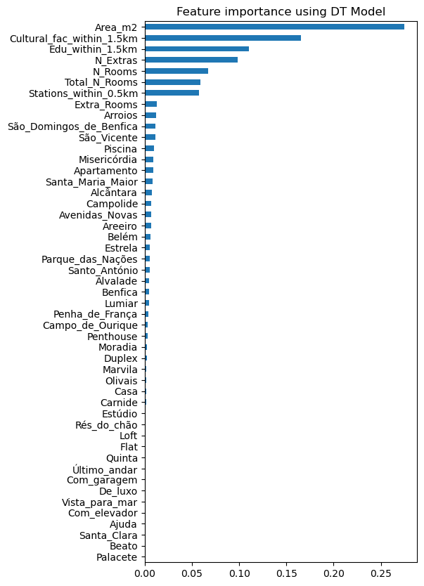

```
_________________________________________________________________________________________________

                                     SPLIT 3
_________________________________________________________________________________________________
```

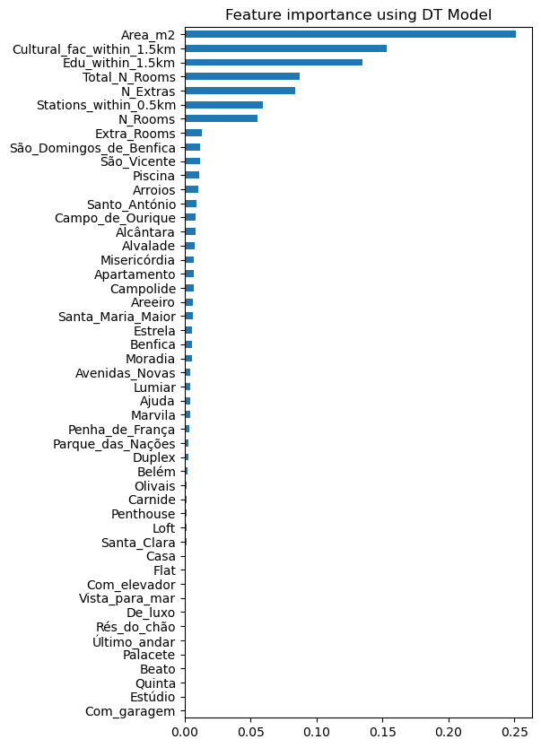

```python
select_best_features_dt(X, y)
```